# Two-generation analysis of pollen flow across a landscape V: a stepwise approach for extracting factors contributing to pollen structure

HEREDITY. 2004.

pollen movement

2gener

gene flow

stamova

Authors

RJ Dyer

RD Westfall

VL Sork

PE Smouse

Published

March 1, 2004

Doi

10.1038/sj.hdy.6800397

[figure not shown]

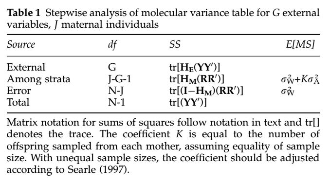

## Abstract

Patterns of pollen dispersal are central to both the ecology and evolution of plant populations. However, the mechanisms controlling either the dispersal process itself or our estimation of that process may be influenced by site-specific factors such as local forest structure and nonuniform adult genetic structure. Here, we present an extension of the AMOVA model applied to the recently developed 2Gener analysis of pollen pool structure. This model, dubbed the Stepwise AMOVA (StAMOVA), focuses on determining to what extent ecological, demographic, and/or environmental factors influence the observed genetic variation in spatially separated pollen pools. The analysis is verified for efficacy, using an extensive battery of simulations, illustrating: ( 1) how nonuniform adult genetic structure influences the differentiation of spatially separated pollen pools, and ( 2) how effectively the Stepwise analysis performs in carrying out the appropriate corrections. Finally, the model is applied to a Quercus alba data set, from which we have prior evidence that the adult genetic structure is nonuniformly distributed across the sampling landscape. From this data set, we show how the Stepwise model can be applied to remove the effects of spatial adult genetic structure on pollen pool differentiation and contrast these results with those derived from the original 2Gener analysis.